# Changepoint Analysis For Fatigue Data

#### P3

The output from the *MVN package* is shown below. Note that we depict the multivariate normal distribution for the three features of each distribution below. **Essentially, the goal here is two-fold. First, we would like to examine if the joint distribution of the three kinematic features can be modeled using the multivariate normal distribution. Second, if the first hypothesis is true, then we can use the Mahalanobis Distance to identify outliers in each observation.**

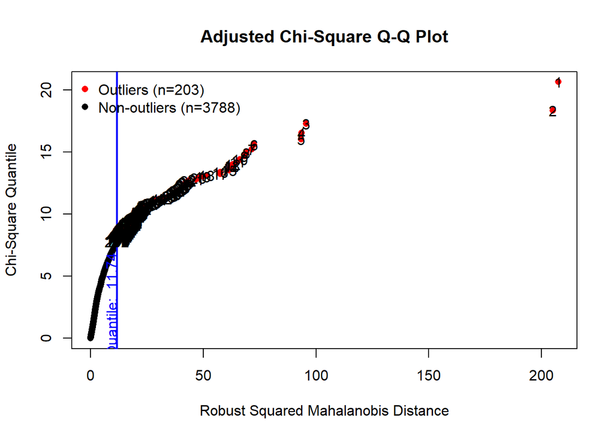

In addition to the plot, we provide the statistics of the Doornik-Hansen test for Participant 3 below.

|  | Test | E | df | p value | MVN |
| --- | --- | --- | --- | --- | --- |
| 1 | Doornik-Hansen | 8137.96 | 6.00 | 0.00 | NO |

Based on the MVN test and the plot above, it is clear that the data is not normally distributed. Thus, an outlier detection/removal algorithm based on a MVN distribution will be inappropriate. This observation is true to not only Participant 3 but to also all the other participants. Thus, in the following section we will investigate method(s) based on the time-series outlier detection literature.

#### P4

The output from the *MVN package* is shown below. Note that we depict the multivariate normal distribution for the three features of each distribution below. **Essentially, the goal here is two-fold. First, we would like to examine if the joint distribution of the three kinematic features can be modeled using the multivariate normal distribution. Second, if the first hypothesis is true, then we can use the Mahalanobis Distance to identify outliers in each observation.**

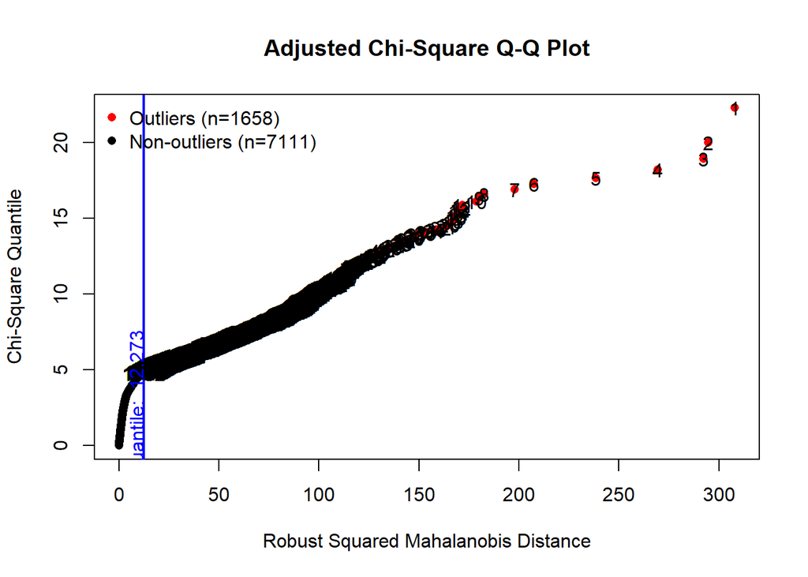

In addition to the plot, we provide the statistics of the Doornik-Hansen test for Participant 4 below.

|  | Test | E | df | p value | MVN |
| --- | --- | --- | --- | --- | --- |
| 1 | Doornik-Hansen | 11169.45 | 6.00 | 0.00 | NO |

Based on the MVN test and the plot above, it is clear that the data is not normally distributed. Thus, an outlier detection/removal algorithm based on a MVN distribution will be inappropriate. This observation is true to not only Participant 4 but to also all the other participants. Thus, in the following section we will investigate method(s) based on the time-series outlier detection literature.

#### P5

The output from the *MVN package* is shown below. Note that we depict the multivariate normal distribution for the three features of each distribution below. **Essentially, the goal here is two-fold. First, we would like to examine if the joint distribution of the three kinematic features can be modeled using the multivariate normal distribution. Second, if the first hypothesis is true, then we can use the Mahalanobis Distance to identify outliers in each observation.**

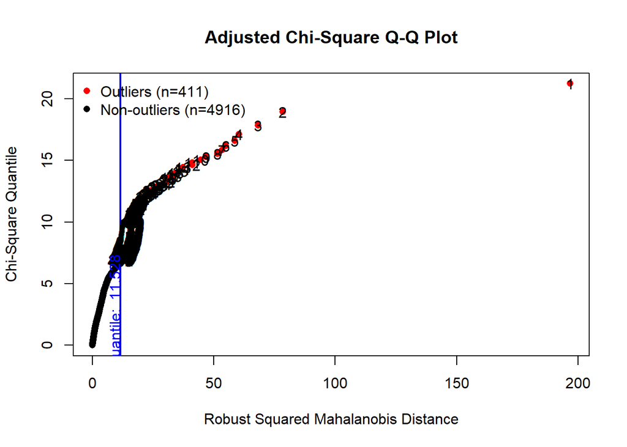

In addition to the plot, we provide the statistics of the Doornik-Hansen test for Participant 5 below.

|  | Test | E | df | p value | MVN |
| --- | --- | --- | --- | --- | --- |
| 1 | Doornik-Hansen | 14420.02 | 6.00 | 0.00 | NO |

Based on the MVN test and the plot above, it is clear that the data is not normally distributed. Thus, an outlier detection/removal algorithm based on a MVN distribution will be inappropriate. This observation is true to not only Participant 5 but to also all the other participants. Thus, in the following section we will investigate method(s) based on the time-series outlier detection literature.

#### P6

The output from the *MVN package* is shown below. Note that we depict the multivariate normal distribution for the three features of each distribution below. **Essentially, the goal here is two-fold. First, we would like to examine if the joint distribution of the three kinematic features can be modeled using the multivariate normal distribution. Second, if the first hypothesis is true, then we can use the Mahalanobis Distance to identify outliers in each observation.**

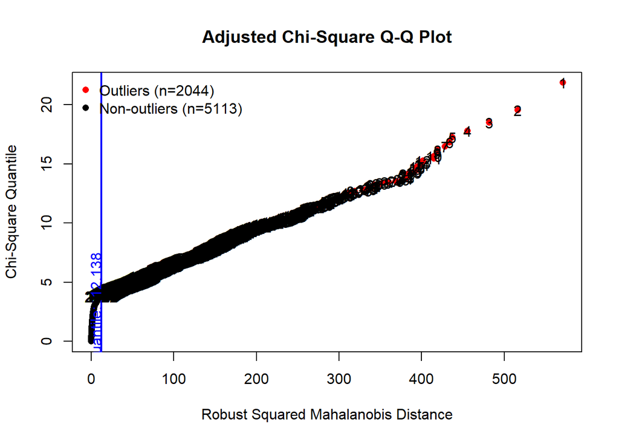

In addition to the plot, we provide the statistics of the Doornik-Hansen test for Participant 6 below.

|  | Test | E | df | p value | MVN |
| --- | --- | --- | --- | --- | --- |
| 1 | Doornik-Hansen | 19339.82 | 6.00 | 0.00 | NO |

Based on the MVN test and the plot above, it is clear that the data is not normally distributed. Thus, an outlier detection/removal algorithm based on a MVN distribution will be inappropriate. This observation is true to not only Participant 6 but to also all the other participants. Thus, in the following section we will investigate method(s) based on the time-series outlier detection literature.

#### P7

The output from the *MVN package* is shown below. Note that we depict the multivariate normal distribution for the three features of each distribution below. **Essentially, the goal here is two-fold. First, we would like to examine if the joint distribution of the three kinematic features can be modeled using the multivariate normal distribution. Second, if the first hypothesis is true, then we can use the Mahalanobis Distance to identify outliers in each observation.**

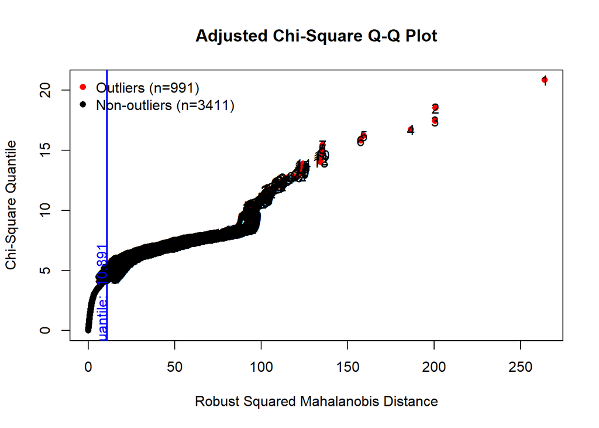

In addition to the plot, we provide the statistics of the Doornik-Hansen test for Participant 7 below.

|  | Test | E | df | p value | MVN |
| --- | --- | --- | --- | --- | --- |
| 1 | Doornik-Hansen | 9900.47 | 6.00 | 0.00 | NO |

Based on the MVN test and the plot above, it is clear that the data is not normally distributed. Thus, an outlier detection/removal algorithm based on a MVN distribution will be inappropriate. This observation is true to not only Participant 7 but to also all the other participants. Thus, in the following section we will investigate method(s) based on the time-series outlier detection literature.

#### P8

The output from the *MVN package* is shown below. Note that we depict the multivariate normal distribution for the three features of each distribution below. **Essentially, the goal here is two-fold. First, we would like to examine if the joint distribution of the three kinematic features can be modeled using the multivariate normal distribution. Second, if the first hypothesis is true, then we can use the Mahalanobis Distance to identify outliers in each observation.**

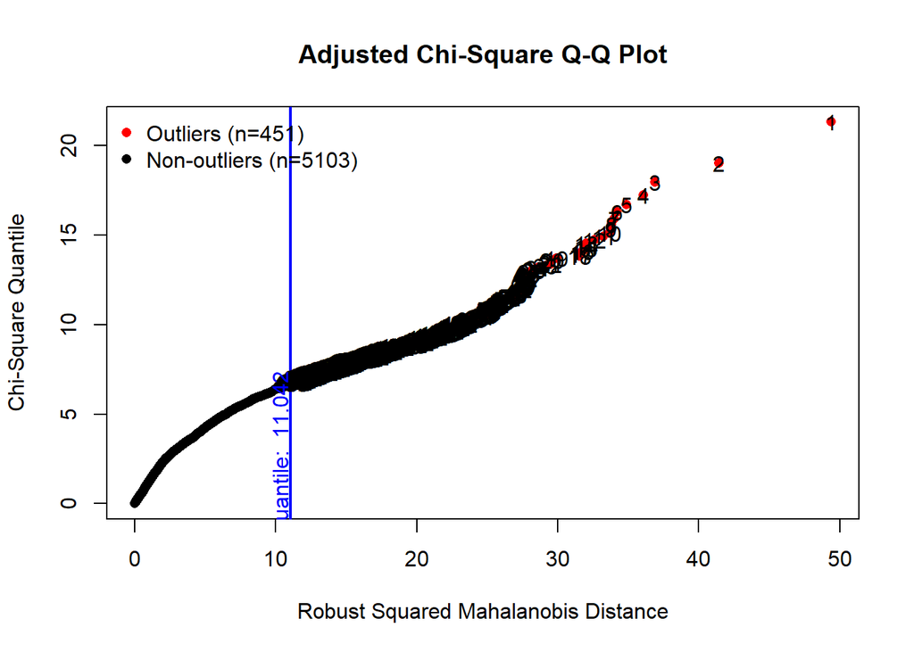

In addition to the plot, we provide the statistics of the Doornik-Hansen test for Participant 8 below.

|  | Test | E | df | p value | MVN |
| --- | --- | --- | --- | --- | --- |
| 1 | Doornik-Hansen | 6758.59 | 6.00 | 0.00 | NO |

Based on the MVN test and the plot above, it is clear that the data is not normally distributed. Thus, an outlier detection/removal algorithm based on a MVN distribution will be inappropriate. This observation is true to not only Participant 8 but to also all the other participants. Thus, in the following section we will investigate method(s) based on the time-series outlier detection literature.

#### P9

The output from the *MVN package* is shown below. Note that we depict the multivariate normal distribution for the three features of each distribution below. **Essentially, the goal here is two-fold. First, we would like to examine if the joint distribution of the three kinematic features can be modeled using the multivariate normal distribution. Second, if the first hypothesis is true, then we can use the Mahalanobis Distance to identify outliers in each observation.**

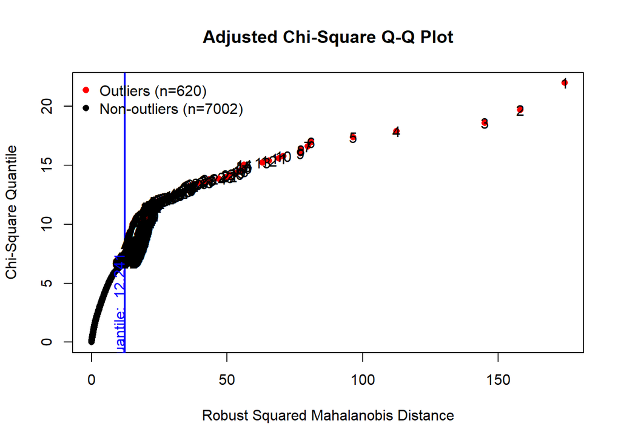

In addition to the plot, we provide the statistics of the Doornik-Hansen test for Participant 9 below.

|  | Test | E | df | p value | MVN |
| --- | --- | --- | --- | --- | --- |
| 1 | Doornik-Hansen | 20458.61 | 6.00 | 0.00 | NO |

Based on the MVN test and the plot above, it is clear that the data is not normally distributed. Thus, an outlier detection/removal algorithm based on a MVN distribution will be inappropriate. This observation is true to not only Participant 9 but to also all the other participants. Thus, in the following section we will investigate method(s) based on the time-series outlier detection literature.

#### P10

The output from the *MVN package* is shown below. Note that we depict the multivariate normal distribution for the three features of each distribution below. **Essentially, the goal here is two-fold. First, we would like to examine if the joint distribution of the three kinematic features can be modeled using the multivariate normal distribution. Second, if the first hypothesis is true, then we can use the Mahalanobis Distance to identify outliers in each observation.**

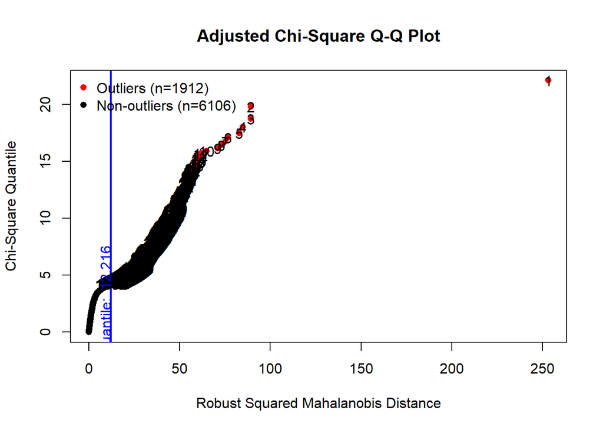

In addition to the plot, we provide the statistics of the Doornik-Hansen test for Participant 10 below.

|  | Test | E | df | p value | MVN |
| --- | --- | --- | --- | --- | --- |
| 1 | Doornik-Hansen | 9436.39 | 6.00 | 0.00 | NO |

Based on the MVN test and the plot above, it is clear that the data is not normally distributed. Thus, an outlier detection/removal algorithm based on a MVN distribution will be inappropriate. This observation is true to not only Participant 10 but to also all the other participants. Thus, in the following section we will investigate method(s) based on the time-series outlier detection literature.

#### P11

The output from the *MVN package* is shown below. Note that we depict the multivariate normal distribution for the three features of each distribution below. **Essentially, the goal here is two-fold. First, we would like to examine if the joint distribution of the three kinematic features can be modeled using the multivariate normal distribution. Second, if the first hypothesis is true, then we can use the Mahalanobis Distance to identify outliers in each observation.**

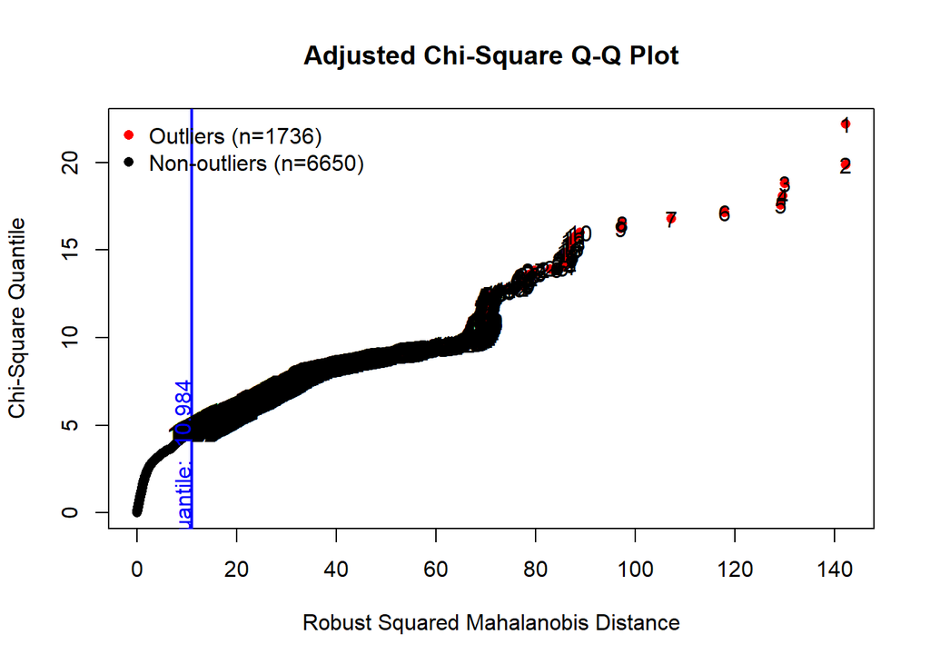

In addition to the plot, we provide the statistics of the Doornik-Hansen test for Participant 11 below.

|  | Test | E | df | p value | MVN |
| --- | --- | --- | --- | --- | --- |
| 1 | Doornik-Hansen | 15641.71 | 6.00 | 0.00 | NO |

Based on the MVN test and the plot above, it is clear that the data is not normally distributed. Thus, an outlier detection/removal algorithm based on a MVN distribution will be inappropriate. This observation is true to not only Participant 11 but to also all the other participants. Thus, in the following section we will investigate method(s) based on the time-series outlier detection literature.

#### P12

The output from the *MVN package* is shown below. Note that we depict the multivariate normal distribution for the three features of each distribution below. **Essentially, the goal here is two-fold. First, we would like to examine if the joint distribution of the three kinematic features can be modeled using the multivariate normal distribution. Second, if the first hypothesis is true, then we can use the Mahalanobis Distance to identify outliers in each observation.**

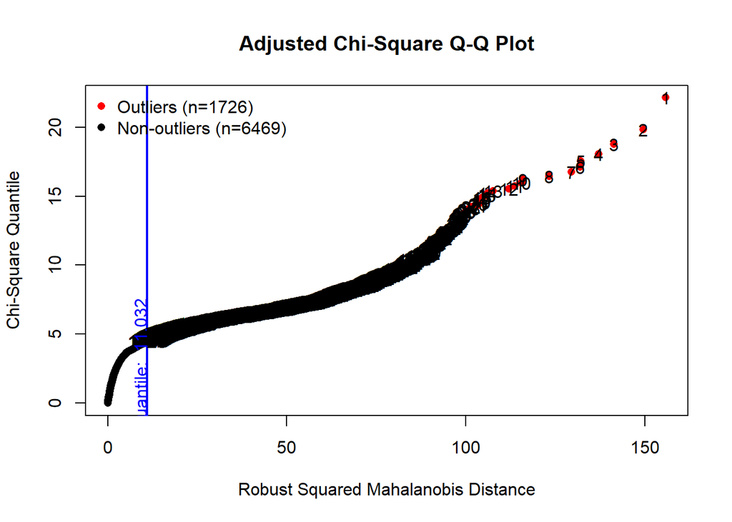

In addition to the plot, we provide the statistics of the Doornik-Hansen test for Participant 12 below.

|  | Test | E | df | p value | MVN |
| --- | --- | --- | --- | --- | --- |
| 1 | Doornik-Hansen | 7947.39 | 6.00 | 0.00 | NO |

Based on the MVN test and the plot above, it is clear that the data is not normally distributed. Thus, an outlier detection/removal algorithm based on a MVN distribution will be inappropriate. This observation is true to not only Participant 12 but to also all the other participants. Thus, in the following section we will investigate method(s) based on the time-series outlier detection literature.

#### P13

The output from the *MVN package* is shown below. Note that we depict the multivariate normal distribution for the three features of each distribution below. **Essentially, the goal here is two-fold. First, we would like to examine if the joint distribution of the three kinematic features can be modeled using the multivariate normal distribution. Second, if the first hypothesis is true, then we can use the Mahalanobis Distance to identify outliers in each observation.**

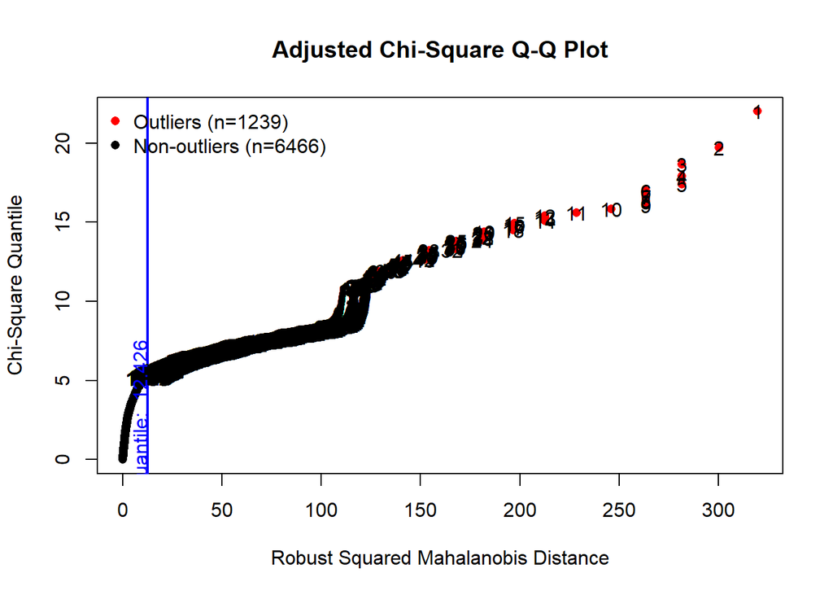

In addition to the plot, we provide the statistics of the Doornik-Hansen test for Participant 13 below.

|  | Test | E | df | p value | MVN |
| --- | --- | --- | --- | --- | --- |
| 1 | Doornik-Hansen | 16868.94 | 6.00 | 0.00 | NO |

Based on the MVN test and the plot above, it is clear that the data is not normally distributed. Thus, an outlier detection/removal algorithm based on a MVN distribution will be inappropriate. This observation is true to not only Participant 13 but to also all the other participants. Thus, in the following section we will investigate method(s) based on the time-series outlier detection literature.

#### P14

The output from the *MVN package* is shown below. Note that we depict the multivariate normal distribution for the three features of each distribution below. **Essentially, the goal here is two-fold. First, we would like to examine if the joint distribution of the three kinematic features can be modeled using the multivariate normal distribution. Second, if the first hypothesis is true, then we can use the Mahalanobis Distance to identify outliers in each observation.**

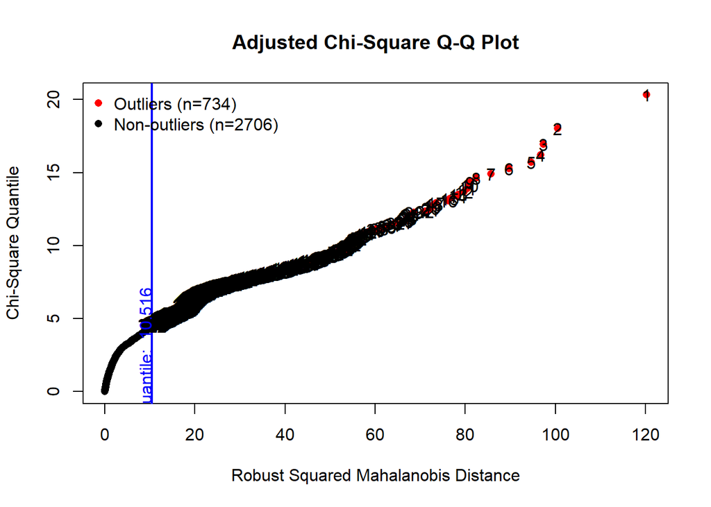

In addition to the plot, we provide the statistics of the Doornik-Hansen test for Participant 14 below.

|  | Test | E | df | p value | MVN |
| --- | --- | --- | --- | --- | --- |
| 1 | Doornik-Hansen | 3642.41 | 6.00 | 0.00 | NO |

Based on the MVN test and the plot above, it is clear that the data is not normally distributed. Thus, an outlier detection/removal algorithm based on a MVN distribution will be inappropriate. This observation is true to not only Participant 14 but to also all the other participants. Thus, in the following section we will investigate method(s) based on the time-series outlier detection literature.

#### P15

The output from the *MVN package* is shown below. Note that we depict the multivariate normal distribution for the three features of each distribution below. **Essentially, the goal here is two-fold. First, we would like to examine if the joint distribution of the three kinematic features can be modeled using the multivariate normal distribution. Second, if the first hypothesis is true, then we can use the Mahalanobis Distance to identify outliers in each observation.**

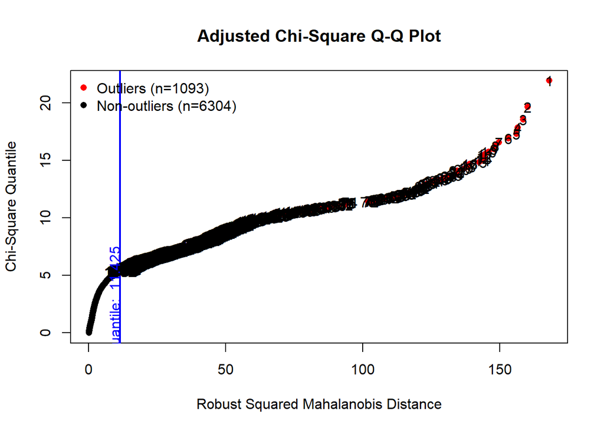

In addition to the plot, we provide the statistics of the Doornik-Hansen test for Participant 15 below.

|  | Test | E | df | p value | MVN |
| --- | --- | --- | --- | --- | --- |
| 1 | Doornik-Hansen | 7662.67 | 6.00 | 0.00 | NO |

Based on the MVN test and the plot above, it is clear that the data is not normally distributed. Thus, an outlier detection/removal algorithm based on a MVN distribution will be inappropriate. This observation is true to not only Participant 15 but to also all the other participants. Thus, in the following section we will investigate method(s) based on the time-series outlier detection literature.

### 2.2.3 Time-Series based Methods

We will need to read about the following methods:

1. The ecp package, which provides some insights into a multivariate (time-series?) based method.
2. The anomalize package, which provides the following:
1. Two univariate implementations based on the interquartile range and the generalized extreme studentized test. Note that their default of the IQR is different than base **R** (and that of most standard statistical textbooks). They use 3 simialr to that found in the forecast package’s *tsoutlier()* function.
2. For time-series implementations, the anomalize package presents two additional methods *stl* and *twitter (twitter decomposition)*, which are inputs to its *time_decompose()* function.
[^1]: Department of Mechanical and Aerospace Engineering, University at Buffalo
[^2]: Department of Industrial and Systems Engineering, University at Buffalo
[^3]: Farmer School of Business, Miami University
[^4]: Farmer School of Business, Miami University. This author can be reached by email at fmegahed@miamioh.edu.